# Covid-19 infección en Ecuador. Modelos matemáticos y predicciones

Una comparación de modelos, lineal, polilnomico,logísticos y exponenciales aplicados a la infección por el virus Covid-19

Se realiza un análisis matemático simple del crecimiento de la infección en Python y dos modelos para comprender mejor la evolución de la infección.

Se crea modelos de series temporales del número total de personas infectadas hasta la fecha (es decir, las personas realmente infectadas más las personas que han sido infectadas). Estos modelos tienen parámetros , que se estimarán por ajuste de curva.

```python
# Importar las librerias para el analasis
import pandas as pd
import numpy as np
import sympy as sym
from datetime import datetime,timedelta
from sklearn.metrics import mean_squared_error
from scipy.optimize import curve_fit
from scipy.optimize import fsolve
from sklearn import linear_model
import matplotlib.pyplot as plt
%matplotlib inline
print("cargo")
```

```
cargo
```

```python
# Actualizar los datos (URL)

url = 'http://cowid.netlify.com/data/full_data.csv'

df = pd.read_csv(url)
df
```

|  | date | location | new_cases | new_deaths | total_cases | total_deaths |
| --- | --- | --- | --- | --- | --- | --- |
| 0 | 2020-02-25 | Afghanistan | NaN | NaN | 1 | NaN |
| 1 | 2020-02-26 | Afghanistan | 0.0 | NaN | 1 | NaN |
| 2 | 2020-02-27 | Afghanistan | 0.0 | NaN | 1 | NaN |
| 3 | 2020-02-28 | Afghanistan | 0.0 | NaN | 1 | NaN |
| 4 | 2020-02-29 | Afghanistan | 0.0 | NaN | 1 | NaN |
| 5 | 2020-03-01 | Afghanistan | 0.0 | NaN | 1 | NaN |
| 6 | 2020-03-02 | Afghanistan | 0.0 | NaN | 1 | NaN |
| 7 | 2020-03-03 | Afghanistan | 0.0 | NaN | 1 | NaN |
| 8 | 2020-03-04 | Afghanistan | 0.0 | NaN | 1 | NaN |
| 9 | 2020-03-05 | Afghanistan | 0.0 | NaN | 1 | NaN |
| 10 | 2020-03-06 | Afghanistan | 0.0 | NaN | 1 | NaN |
| 11 | 2020-03-07 | Afghanistan | 0.0 | NaN | 1 | NaN |
| 12 | 2020-03-08 | Afghanistan | 3.0 | NaN | 4 | NaN |
| 13 | 2020-03-09 | Afghanistan | 0.0 | NaN | 4 | NaN |
| 14 | 2020-03-10 | Afghanistan | 0.0 | NaN | 4 | NaN |
| 15 | 2020-03-11 | Afghanistan | 0.0 | NaN | 4 | NaN |
| 16 | 2020-03-12 | Afghanistan | 3.0 | NaN | 7 | NaN |
| 17 | 2020-03-13 | Afghanistan | 0.0 | NaN | 7 | NaN |
| 18 | 2020-03-14 | Afghanistan | 0.0 | NaN | 7 | NaN |
| 19 | 2020-03-15 | Afghanistan | 3.0 | NaN | 10 | NaN |
| 20 | 2020-03-16 | Afghanistan | 6.0 | NaN | 16 | NaN |
| 21 | 2020-03-17 | Afghanistan | 5.0 | NaN | 21 | NaN |
| 22 | 2020-03-09 | Albania | NaN | NaN | 2 | NaN |
| 23 | 2020-03-10 | Albania | 0.0 | NaN | 2 | NaN |
| 24 | 2020-03-11 | Albania | 8.0 | NaN | 10 | NaN |
| 25 | 2020-03-12 | Albania | 0.0 | NaN | 10 | NaN |
| 26 | 2020-03-13 | Albania | 13.0 | NaN | 23 | NaN |
| 27 | 2020-03-14 | Albania | 10.0 | NaN | 33 | 1.0 |
| 28 | 2020-03-15 | Albania | 5.0 | 0.0 | 38 | 1.0 |
| 29 | 2020-03-16 | Albania | 4.0 | 0.0 | 42 | 1.0 |
| ... | ... | ... | ... | ... | ... | ... |
| 2837 | 2020-02-17 | World | 19572.0 | 106.0 | 71429 | 1775.0 |
| 2838 | 2020-02-18 | World | 1903.0 | 98.0 | 73332 | 1873.0 |
| 2839 | 2020-02-19 | World | 1872.0 | 136.0 | 75204 | 2009.0 |
| 2840 | 2020-02-20 | World | 542.0 | 115.0 | 75748 | 2129.0 |
| 2841 | 2020-02-21 | World | 1021.0 | 118.0 | 76769 | 2247.0 |
| 2842 | 2020-02-22 | World | 1023.0 | 112.0 | 77794 | 2359.0 |
| 2843 | 2020-02-23 | World | 1017.0 | 102.0 | 78811 | 2463.0 |
| 2844 | 2020-02-24 | World | 517.0 | 155.0 | 79331 | 2618.0 |
| 2845 | 2020-02-25 | World | 896.0 | 82.0 | 80239 | 2700.0 |
| 2846 | 2020-02-26 | World | 864.0 | 62.0 | 81109 | 2762.0 |
| 2847 | 2020-02-27 | World | 1175.0 | 42.0 | 82294 | 2804.0 |
| 2848 | 2020-02-28 | World | 1353.0 | 54.0 | 83652 | 2858.0 |
| 2849 | 2020-02-29 | World | 1748.0 | 66.0 | 85403 | 2924.0 |
| 2850 | 2020-03-01 | World | 1727.0 | 53.0 | 87137 | 2977.0 |
| 2851 | 2020-03-02 | World | 1801.0 | 64.0 | 88948 | 3043.0 |
| 2852 | 2020-03-03 | World | 1912.0 | 67.0 | 90869 | 3112.0 |
| 2853 | 2020-03-04 | World | 2217.0 | 86.0 | 93090 | 3198.0 |
| 2854 | 2020-03-05 | World | 2220.0 | 79.0 | 95324 | 3280.0 |
| 2855 | 2020-03-06 | World | 2864.0 | 99.0 | 98192 | 3380.0 |
| 2856 | 2020-03-07 | World | 3730.0 | 104.0 | 101927 | 3486.0 |
| 2857 | 2020-03-08 | World | 3644.0 | 96.0 | 105592 | 3584.0 |
| 2858 | 2020-03-09 | World | 3979.0 | 224.0 | 109577 | 3809.0 |
| 2859 | 2020-03-10 | World | 4119.0 | 201.0 | 113702 | 4012.0 |
| 2860 | 2020-03-11 | World | 4611.0 | 275.0 | 118319 | 4292.0 |
| 2861 | 2020-03-12 | World | 6936.0 | 317.0 | 125260 | 4613.0 |
| 2862 | 2020-03-13 | World | 7488.0 | 338.0 | 132758 | 4956.0 |
| 2863 | 2020-03-14 | World | 9761.0 | 433.0 | 142534 | 5392.0 |
| 2864 | 2020-03-15 | World | 10967.0 | 343.0 | 153517 | 5735.0 |
| 2865 | 2020-03-16 | World | 13971.0 | 855.0 | 167506 | 6606.0 |
| 2866 | 2020-03-17 | World | 11594.0 | 819.0 | 179112 | 7426.0 |

2867 rows × 6 columns

Imprimos los resultados y agregamos el numero del dia

```python
df = df[df['location'].isin(['Ecuador'])] #Filtro la Informacion solo para Ecuador
df = df.loc[:,['date','total_cases']] #Selecciono las columnas de analasis
# Expresar las fechas en numero de dias desde el 01 Enero
FMT = '%Y-%m-%d'
date = df['date']
df['date'] = date.map(lambda x : (datetime.strptime(x, FMT) - datetime.strptime("2020-01-01", FMT)).days)

df
```

|  | date | total_cases |
| --- | --- | --- |
| 681 | 60 | 1 |
| 682 | 61 | 1 |
| 683 | 62 | 6 |
| 684 | 63 | 7 |
| 685 | 64 | 7 |
| 686 | 65 | 13 |
| 687 | 66 | 14 |
| 688 | 67 | 14 |
| 689 | 68 | 15 |
| 690 | 69 | 15 |
| 691 | 70 | 15 |
| 692 | 71 | 17 |
| 693 | 72 | 17 |
| 694 | 73 | 23 |
| 695 | 74 | 23 |
| 696 | 75 | 37 |
| 697 | 76 | 58 |

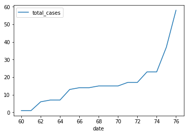

```python
df.plot(x ='date', y='total_cases')
```